# Network Analysis with Juglans nigra microbiome

## Figures

In the final analysis, we produced figures for all networks (all p- and r- cutoff combinations, states, and compartments- stem and bulk soil). This amount of analysis is not practical for an R markdown, but to facilitate it we wrote a function that produces the desired figure, with and without small, disconnected subnetworks, highlighting bacteria in black, fungi in red, and hub taxa with closed circles. Positive and negative correlations are depicted in different colors. Geosmithia morbida is plotted in green.

```r
figure.network <- function (p, r, s, subs=F) {

  # the aruments to this function ar p (p cutoff), r (r cutoff), s (state)
  # and whether you want to include subnetworks in the plot (subs)

  # make a graph object from the network
  gr <- read.csv(paste("Net.analysis/CorrNetworks.", s,"/cyto.shavings.merged.p.", p, ".r.", r,".txt", sep = ''), sep='\t')[,1:3] %>% as.matrix() %>% graph_from_data_frame(directed =F)

  # create edge attributes for positive and negative sign correlations and absolute value of the correlation
  edge_attr(gr, name= 'r.sign') <- read.csv(paste("Net.analysis/CorrNetworks.", s,"/cyto.shavings.merged.p.", p, ".r.", r,".txt", sep = ''), sep='\t')[,3] %>% sign() %>% as.factor()
  edge_attr(gr, name= 'r.abs') <- read.csv(paste("Net.analysis/CorrNetworks.", s,"/cyto.shavings.merged.p.", p, ".r.", r,".txt", sep = ''), sep='\t')[,3] %>% abs() %>% as.numeric()

  # create vertex attributes for degree and fungus vs bacteria
  vertex_attr(gr, name='deg') <- degree(gr)
  vertex_attr(gr, name='fu.ba') <- (vertex_attr(gr, 'name') %>% grepl('Botu',.) ) %>% as.numeric()

  # create another vertex attribute for whether a vertex was a hub taxa in our results
  bd.tab <- read.csv(paste("Results/Shavings.HubOTUS.", s, ".csv", sep=""), row.names = 1)
  vertex_attr(gr, name='hub') <- vertex_attr(gr, 'name') %in% rownames(bd.tab)[bd.tab[, paste("p",p,".r",r,sep="")] == 1] %>% as.numeric()

  # if in Washington, find Geosmithia morbida (Otu0115) and modify the vertex attributes so it can be
  # coded along with hub and fungus/bacteria, so it can be plotted in a different color and shape
  if (s == "WA") {
    vertex_attr(gr, name='hub') <- ((((vertex_attr(gr, 'name') == 'Otu0115' )) %>% as.numeric) + vertex_attr(gr, name='hub'))
    vertex_attr(gr, name='fu.ba') <- ((((vertex_attr(gr, 'name') == 'Otu0115' )) %>% as.numeric)*2 + vertex_attr(gr, name='fu.ba'))
  }

  # if sub networks are not desired, remove them and just plot the biggest one
  if (!subs) {
    dec.subrs <- decompose.graph(gr) # breaks up graph into subnetworks
    cl.gr.i <- which.max(clusters(gr)$csize) # figures out the biggest subnetwork
    gr <- dec.subrs[[cl.gr.i]] # replaces our graph object with just the big subnetwork
  }

  # create a layout 'kk' Kamada-Kawai
  # weights= 2-as.numeric(edge_attr(gr, 'r'))
  # allows the negative correlations to be plotted
  # farther away from each other. 2 - r will be close
  # to 1 for positive correlations, plotting them close
  # together, whereas close to 3 for strong negative correlations.
  layout <- layout_with_kk(gr, weights=2-as.numeric(edge_attr(gr, 'r')))

  # now graph with the layout object and return the resulting
  # graph object as output from this funtion

  ggraph(gr, layout) +
    geom_edge_link(aes(width=.1, alpha=r.abs, color=as.factor(r.sign))) +
    scale_edge_color_manual(values=c('grey','blue')) +
    scale_edge_width(range=c(0.2,1)) +
    geom_node_point(aes(size=deg, shape=as.factor(hub), color=as.factor(fu.ba))) +
    scale_size(range = c(.2,2.5)) + scale_color_manual(values=c('red','black','green')) +
    scale_shape_manual(values=c(1,19,8)) +
    theme_graph() +
    theme(legend.position='none')

}
```

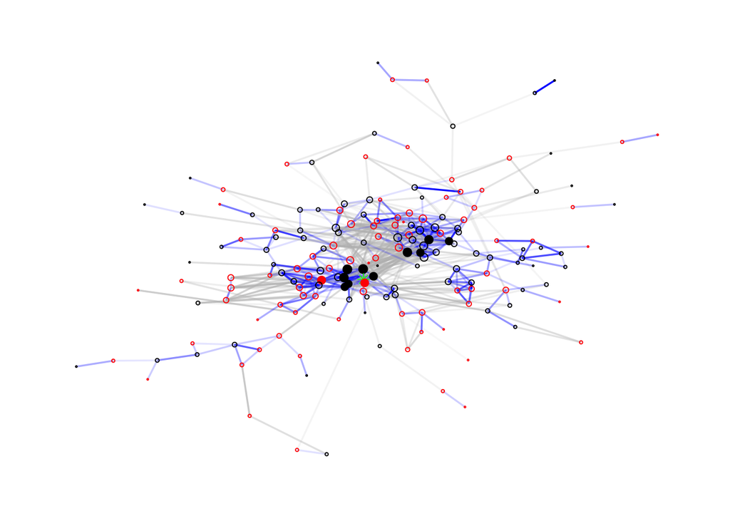

```r
p<-"0.01"
r<-"0.8"
figure.network(p, r, "WA")
```

We could make a multipanel plot as well, and since the results of this analysis are already saved, I can give an example of that as well.

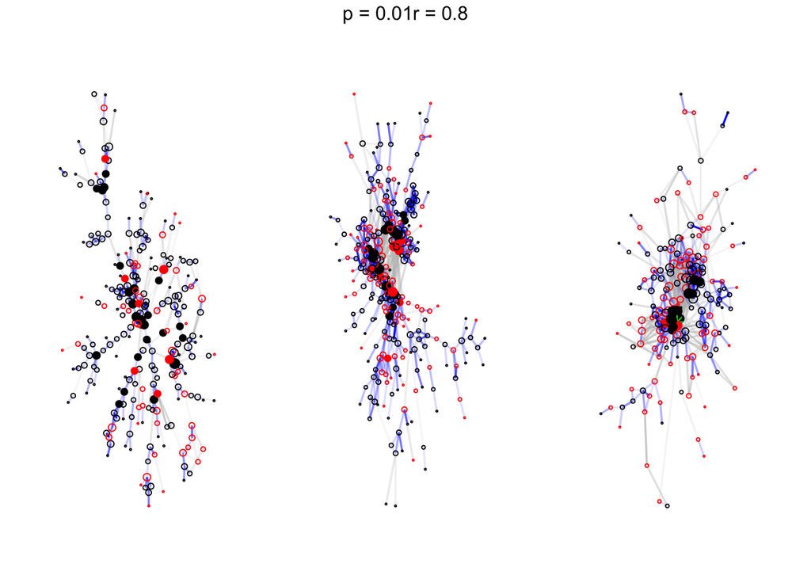

```r
p<-"0.01"
r<-"0.8"
grid.arrange(
  figure.network(p, r, "IN"),
  figure.network(p, r, "TN"),
  figure.network(p, r, "WA"),
  nrow=1,
  top=paste("p = ", p, "r = ", r, sep="")
)
```

Finally, I include the full loop to make all the figures and save them below.

```r
#for (p in c("0.05","0.01","0.005", "0.001")) {
#  for (r in c("0.6","0.8")) {
#
#    pdf(paste("Net.analysis/Net.figures/Shavings/Allstates.networks.caulo.", "p", p, ".r", r, ".nosubnets.pdf", sep=""), width=12, height=6)

#    grid.arrange(
#      figure.network(p, r, "IN"),
#      figure.network(p, r, "TN"),
#      figure.network(p, r, "WA"),
#      nrow=1,
#      top=paste("p = ", p, "r = ", r, sep="")
#    )

#    dev.off()

#    pdf(paste("Net.analysis/Net.figures/Shavings/Subnetworks/Allstates.networks.caulo.", "p", p, ".r", r, ".wsubnets.pdf", sep=""), width=12, height=6)

#    grid.arrange(
#      figure.network(p, r, "IN", T),
#      figure.network(p, r, "TN", T),
#      figure.network(p, r, "WA", T),
#      nrow=1,
#      top=paste("p = ", p, "r = ", r, sep="")
#    )

#    dev.off()

#  }}
```